# Module 187

#### Hemi-module gene counts:

574 probesets in hemi-module A.  
42 probesets in hemi-module B.  
Note: While the mapping of probesets to genes is usually one-to-one, some genes are targeted by multiple probesets, some probesets target multiple genes, and some probesets do not target any genes (i.e., the region of the genome they match is no longer considered genic).

#### Contrast SVE:

Signed variance explained (SVE) provides an indication of how similar a set of fold changes are to a gene module’s weight vector. An SVE value of 0.3, for example, indicates that 30% of the variance explained by the entire module set is accounted for by the module in question. Shown here are the SVE values for this module across a compendium of fold changes (contrasts). Extreme SVE values (e.g., > 0.05) indicate that those contrasts specifically induce (orange dots) or specifically repress (blue dots) this module. Examining the experimental conditions being compared in such contrasts (see tables below the figure) may provide insight into the gene module’s function.

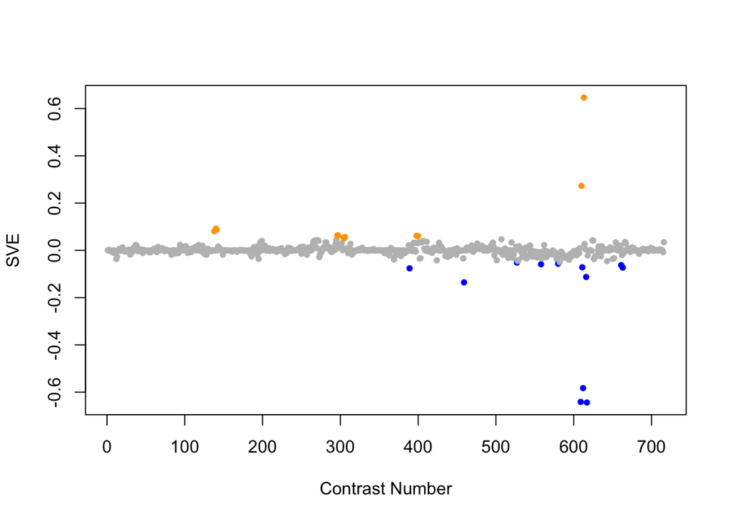

Positive SVE Contrasts:

|  | Contrast.Num | SVE | GEO.GSE | Cond.1 | Cond.2 | Mutation |
| --- | --- | --- | --- | --- | --- | --- |
| GSE21591.s3t1.vs.s4t1 | 613 | 0.65 | GSE21591 | GGF_aFLAG_1 | aMYC_1 |  |
| GSE21591.s3t1.vs.s5t1 | 610 | 0.27 | GSE21591 | GGF_aFLAG_1 | aFLAG_1 |  |
| GSE51691.s4t1.vs.s2t1 | 140 | 0.09 | GSE51691 | day8 hermaphrodite utx-1 RNAi +males rep 1 | day8 hermaphrodite +males rep 1 | utx-1(RNAi) |
| GSE51691.s4t1.vs.s3t1 | 141 | 0.09 | GSE51691 | day8 hermaphrodite utx-1 RNAi +males rep 1 | day8 hermaphrodite utx-1 RNAi -males rep 1 |  |
| GSE51691.s4t1.vs.s1t1 | 138 | 0.08 | GSE51691 | day8 hermaphrodite utx-1 RNAi +males rep 1 | day8 hermaphrodite -males rep 1 |  |
| GSE41366C.s0t6.vs.s0t1 | 297 | 0.06 | GSE41366 | control-continuous_expose-26h_harvest-rep1 | control-continuous_expose-0h_harvest-rep2 |  |
| GSE41366C.s0t5.vs.s0t1 | 296 | 0.06 | GSE41366 | control-continuous_expose-20h_harvest-rep1 | control-continuous_expose-0h_harvest-rep2 |  |
| GSE30505.s2t2.vs.s4t2 | 398 | 0.06 | GSE30505 | Day 8 N2 (WT) ash-2 #1 | Day 8 glp-1 ash-2 #1 | glp-1 |
| GSE30505.s2t2.vs.s3t2 | 400 | 0.06 | GSE30505 | Day 8 N2 (WT) ash-2 #1 | Day 8 glp-1 E.V. #1 | ash-2(RNAi) vs. glp-1 |
| GSE41366C.s1t5.vs.s1t1 | 306 | 0.06 | GSE41366 | low_DDVP-continuous_expose-26h_harvest-rep1 | low_DDVP-continuous_expose-2h_harvest-rep1 |  |
| GSE41366C.s1t3.vs.s1t1 | 304 | 0.05 | GSE41366 | low_DDVP-continuous_expose-14h_harvest-rep1 | low_DDVP-continuous_expose-2h_harvest-rep1 |  |
| GSE41366C.s1t4.vs.s1t1 | 305 | 0.05 | GSE41366 | low_DDVP-continuous_expose-20h_harvest-rep1 | low_DDVP-continuous_expose-2h_harvest-rep1 |  |

Negative SVE Contrasts:

|  | Contrast.Num | SVE | GEO.GSE | Cond.1 | Cond.2 | Mutation |
| --- | --- | --- | --- | --- | --- | --- |
| GSE21591.s1t1.vs.s3t1 | 617 | -0.64 | GSE21591 | N2_aFLAG_1 | GGF_aFLAG_1 |  |
| GSE21591.s4t1.vs.s5t1 | 609 | -0.64 | GSE21591 | aMYC_1 | aFLAG_1 |  |
| GSE21591.s1t1.vs.s5t1 | 612 | -0.58 | GSE21591 | N2_aFLAG_1 | aFLAG_1 |  |
| GSE23843B.s1t1.vs.s0t1 | 459 | -0.14 | GSE23843 | RNP-8 rnp-8(q784)-IP, biological replicate 1 | RNP-8 wt-IP, biological replicate 1 |  |
| GSE21591.s2t1.vs.s3t1 | 616 | -0.11 | GSE21591 | Input_1 | GGF_aFLAG_1 |  |
| GSE32942.s2t1.vs.s1t1 | 389 | -0.08 | GSE32942 | WS5041 (mir 58(n4640); alg 1(tm492); opIs205). Replicate 1 | WS4303 (alg 1(tm492); opIs205). Replicate 1 | mir-58 |
| GSE15159.s1t2.vs.s0t2 | 663 | -0.07 | GSE15159 | glp-1_UV_2007_rep1 | N2_UV_2007_rep1 | glp-1 |
| GSE21591.s2t1.vs.s5t1 | 611 | -0.07 | GSE21591 | Input_1 | aFLAG_1 |  |
| GSE15159.s1t1.vs.s0t1 | 661 | -0.06 | GSE15159 | glp-1_control_2007_rep1 | N2_control_2007_rep1 | glp-1 |
| GSE2180.s3t5.vs.s1t5 | 558 | -0.06 | GSE2180 | p66-1 | 66-4 | pie-1(zu154) |
| GSE2180.s2t9.vs.s2t1 | 580 | -0.06 | GSE2180 | ms143-2 | ms0-1 |  |
| GSE2180.s2t9.vs.s1t9 | 527 | -0.05 | GSE2180 | ms143-2 | 143L | mex-3(zu155);skn-1(RNAi) |

$~$

#### Contrast SVE, Up-Regulated Genes Only:

Calculating SVE for up-regulated and down-regulated genes separately may be more informative in many cases than projecting the up- and down- gene sets together. This is due to the fact that the weight distribution of many modules is highly skewed, indicating that only one of the hemi-modules may be biologically meaningful (i.e., a set of genes are strongly correlated by only a few genes (or none) are strongly anti-correlated to that set.)

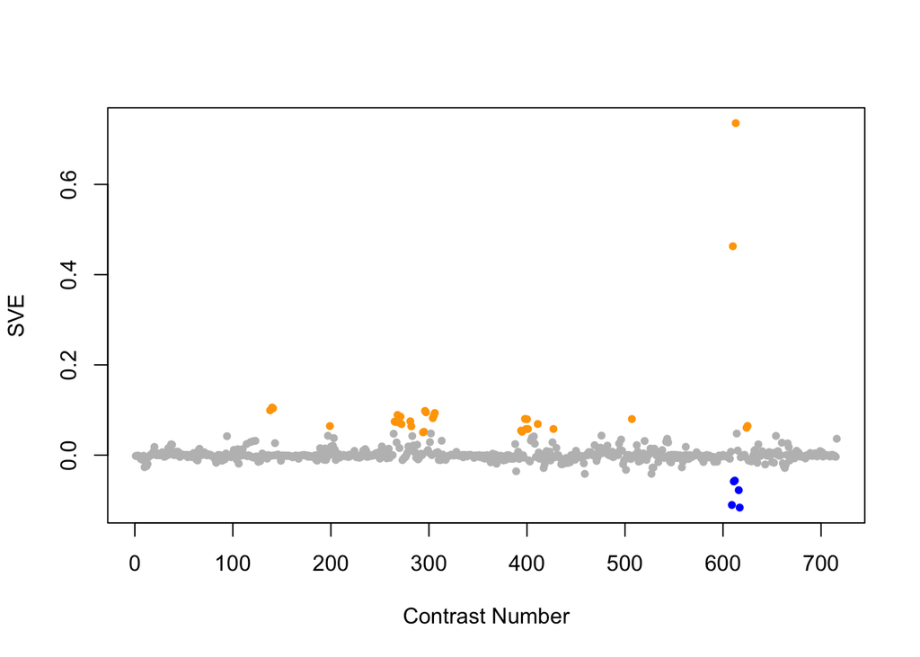

Positive SVE Contrasts:

|  | Contrast.Num | SVE | GEO.GSE | Cond.1 | Cond.2 | Mutation |
| --- | --- | --- | --- | --- | --- | --- |
| GSE21591.s3t1.vs.s4t1 | 613 | 0.74 | GSE21591 | GGF_aFLAG_1 | aMYC_1 |  |
| GSE21591.s3t1.vs.s5t1 | 610 | 0.46 | GSE21591 | GGF_aFLAG_1 | aFLAG_1 |  |
| GSE51691.s4t1.vs.s2t1 | 140 | 0.11 | GSE51691 | day8 hermaphrodite utx-1 RNAi +males rep 1 | day8 hermaphrodite +males rep 1 | utx-1(RNAi) |
| GSE51691.s4t1.vs.s3t1 | 141 | 0.10 | GSE51691 | day8 hermaphrodite utx-1 RNAi +males rep 1 | day8 hermaphrodite utx-1 RNAi -males rep 1 |  |
| GSE51691.s4t1.vs.s1t1 | 138 | 0.10 | GSE51691 | day8 hermaphrodite utx-1 RNAi +males rep 1 | day8 hermaphrodite -males rep 1 |  |
| GSE41366C.s0t5.vs.s0t1 | 296 | 0.10 | GSE41366 | control-continuous_expose-20h_harvest-rep1 | control-continuous_expose-0h_harvest-rep2 |  |
| GSE41366C.s0t6.vs.s0t1 | 297 | 0.09 | GSE41366 | control-continuous_expose-26h_harvest-rep1 | control-continuous_expose-0h_harvest-rep2 |  |
| GSE41366C.s1t5.vs.s1t1 | 306 | 0.09 | GSE41366 | low_DDVP-continuous_expose-26h_harvest-rep1 | low_DDVP-continuous_expose-2h_harvest-rep1 |  |
| GSE41366A.s2t3.vs.s2t1 | 268 | 0.09 | GSE41366 | high_DDVP-2h_expose-20h_harvest-rep1 | high_DDVP-2h_expose-8h_harvest-rep1 |  |
| GSE41366C.s1t4.vs.s1t1 | 305 | 0.09 | GSE41366 | low_DDVP-continuous_expose-20h_harvest-rep1 | low_DDVP-continuous_expose-2h_harvest-rep1 |  |
| GSE41366A.s1t3.vs.s1t1 | 271 | 0.09 | GSE41366 | low_DDVP-2h_expose-20h_harvest-rep1 | low_DDVP-2h_expose-8h_harvest-rep1 |  |
| GSE41366C.s1t3.vs.s1t1 | 304 | 0.08 | GSE41366 | low_DDVP-continuous_expose-14h_harvest-rep1 | low_DDVP-continuous_expose-2h_harvest-rep1 |  |
| GSE30505.s2t2.vs.s4t2 | 398 | 0.08 | GSE30505 | Day 8 N2 (WT) ash-2 #1 | Day 8 glp-1 ash-2 #1 | glp-1 |
| GSE2210.s2t1.vs.s0t1 | 507 | 0.08 | GSE2210 | unc-43(n1186) Sample 1 | Wild type Sample 1 | unc-43 |
| GSE30505.s2t2.vs.s3t2 | 400 | 0.08 | GSE30505 | Day 8 N2 (WT) ash-2 #1 | Day 8 glp-1 E.V. #1 | ash-2(RNAi) vs. glp-1 |
| GSE41366B.s2t2.vs.s2t1 | 281 | 0.08 | GSE41366 | high_DDVP-8h_expose-20h_harvest-rep1 | high_DDVP-8h_expose-14h_harvest-rep1 |  |
| GSE41366A.s0t3.vs.s0t1 | 265 | 0.07 | GSE41366 | control-2h_expose-20h_harvest-rep1 | control-2h_expose-8h_harvest-rep1 |  |
| GSE41366A.s0t4.vs.s0t1 | 266 | 0.07 | GSE41366 | control-2h_expose-26h_harvest-rep1 | control-2h_expose-8h_harvest-rep1 |  |
| GSE41366A.s2t4.vs.s2t1 | 269 | 0.07 | GSE41366 | high_DDVP-2h_expose-26h_harvest-rep1 | high_DDVP-2h_expose-8h_harvest-rep1 |  |
| GSE30505.s2t2.vs.s2t1 | 411 | 0.07 | GSE30505 | Day 8 N2 (WT) ash-2 #1 | L3 N2 (WT) ash-2 #1 |  |
| GSE41366A.s1t4.vs.s1t1 | 272 | 0.07 | GSE41366 | low_DDVP-2h_expose-26h_harvest-rep1 | low_DDVP-2h_expose-8h_harvest-rep1 |  |
| GSE19972.s2t1.vs.s0t1 | 625 | 0.06 | GSE19972 | transgenic myo-4::his-SUMO-1 JS63_1 | control wild type N2_1 |  |
| GSE43959.s1t2.vs.s4t2 | 199 | 0.06 | GSE43959 | N2 gravid adult on E. coli OP50 rep 1 | N2 gravid adult on 1:1000 Comamonas DA1877 rep 1 |  |
| GSE41366B.s2t3.vs.s2t1 | 282 | 0.06 | GSE41366 | high_DDVP-8h_expose-26h_harvest-rep1 | high_DDVP-8h_expose-14h_harvest-rep1 |  |
| GSE19972.s1t1.vs.s0t1 | 624 | 0.06 | GSE19972 | transgenic aex-3::his-SUMO-1 JS62_1 | control wild type N2_1 |  |
| GSE27677A.s1t2.vs.s0t2 | 427 | 0.06 | GSE27677 | kgb-1, Fast , rep 1 | N2, Fast , rep 1 | kgb-1 |
| GSE30505.s1t2.vs.s4t2 | 399 | 0.06 | GSE30505 | Day 8 N2 (WT) E.V. #1 | Day 8 glp-1 ash-2 #1 | glp-1; ash-2 |
| GSE30505.s1t2.vs.s3t2 | 401 | 0.06 | GSE30505 | Day 8 N2 (WT) E.V. #1 | Day 8 glp-1 E.V. #1 | glp-1 |
| GSE32339.s1t2.vs.s1t1 | 394 | 0.05 | GSE32339 | Adult Mutant, biological rep1 | Larval Mutant, biological rep1 |  |
| GSE32339.s0t2.vs.s0t1 | 395 | 0.05 | GSE32339 | Adult Wild-type, biological rep1 | Larval Wild-type, biological rep1 |  |
| GSE41366C.s0t4.vs.s0t1 | 295 | 0.05 | GSE41366 | control-continuous_expose-14h_harvest-rep1 | control-continuous_expose-0h_harvest-rep2 |  |
| GSE41366C.s1t3.vs.s0t3 | 294 | 0.05 | GSE41366 | low_DDVP-continuous_expose-14h_harvest-rep1 | control-continuous_expose-8h_harvest-rep1 |  |

Negative SVE Contrasts:

|  | Contrast.Num | SVE | GEO.GSE | Cond.1 | Cond.2 | Mutation |
| --- | --- | --- | --- | --- | --- | --- |
| GSE21591.s1t1.vs.s3t1 | 617 | -0.12 | GSE21591 | N2_aFLAG_1 | GGF_aFLAG_1 |  |
| GSE21591.s4t1.vs.s5t1 | 609 | -0.11 | GSE21591 | aMYC_1 | aFLAG_1 |  |
| GSE21591.s2t1.vs.s3t1 | 616 | -0.08 | GSE21591 | Input_1 | GGF_aFLAG_1 |  |
| GSE21591.s2t1.vs.s5t1 | 611 | -0.06 | GSE21591 | Input_1 | aFLAG_1 |  |
| GSE21591.s1t1.vs.s5t1 | 612 | -0.06 | GSE21591 | N2_aFLAG_1 | aFLAG_1 |  |

$~$

#### Contrast SVE, Down-Regulated Genes Only:

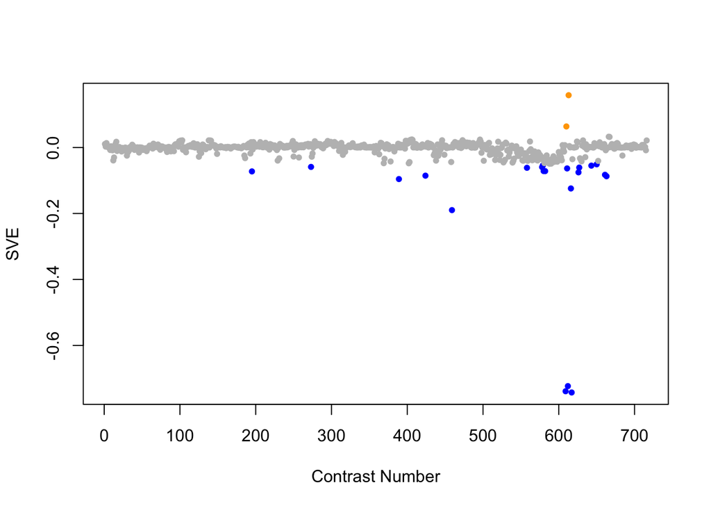

Positive SVE Contrasts:

|  | Contrast.Num | SVE | GEO.GSE | Cond.1 | Cond.2 | Mutation |
| --- | --- | --- | --- | --- | --- | --- |
| GSE21591.s3t1.vs.s4t1 | 613 | 0.16 | GSE21591 | GGF_aFLAG_1 | aMYC_1 |  |
| GSE21591.s3t1.vs.s5t1 | 610 | 0.06 | GSE21591 | GGF_aFLAG_1 | aFLAG_1 |  |
| GSE15159.s0t2.vs.s0t1 | 666 | 0.03 | GSE15159 | N2_UV_2007_rep1 | N2_control_2007_rep1 |  |
| GSE15159.s2t2.vs.s2t1 | 667 | 0.03 | GSE15159 | xpa-1_UV_2007_rep1 | xpa-1_control_2007_rep1 |  |
| GSE30505.s2t1.vs.s3t1 | 406 | 0.02 | GSE30505 | L3 N2 (WT) ash-2 #1 | L3 glp-1 E.V. #1 | ash-2(RNAi) vs. glp-1 |

Negative SVE Contrasts:

|  | Contrast.Num | SVE | GEO.GSE | Cond.1 | Cond.2 | Mutation |
| --- | --- | --- | --- | --- | --- | --- |
| GSE21591.s1t1.vs.s3t1 | 617 | -0.74 | GSE21591 | N2_aFLAG_1 | GGF_aFLAG_1 |  |
| GSE21591.s4t1.vs.s5t1 | 609 | -0.74 | GSE21591 | aMYC_1 | aFLAG_1 |  |
| GSE21591.s1t1.vs.s5t1 | 612 | -0.72 | GSE21591 | N2_aFLAG_1 | aFLAG_1 |  |
| GSE23843B.s1t1.vs.s0t1 | 459 | -0.19 | GSE23843 | RNP-8 rnp-8(q784)-IP, biological replicate 1 | RNP-8 wt-IP, biological replicate 1 |  |
| GSE21591.s2t1.vs.s3t1 | 616 | -0.12 | GSE21591 | Input_1 | GGF_aFLAG_1 |  |
| GSE32942.s2t1.vs.s1t1 | 389 | -0.10 | GSE32942 | WS5041 (mir 58(n4640); alg 1(tm492); opIs205). Replicate 1 | WS4303 (alg 1(tm492); opIs205). Replicate 1 | mir-58 |
| GSE15159.s1t2.vs.s0t2 | 663 | -0.09 | GSE15159 | glp-1_UV_2007_rep1 | N2_UV_2007_rep1 | glp-1 |
| GSE27867.s1t1.vs.s0t1 | 424 | -0.09 | GSE27867 | tag-24, biological rep1 | wt, biological rep1 | tag-24 |
| GSE15159.s1t1.vs.s0t1 | 661 | -0.08 | GSE15159 | glp-1_control_2007_rep1 | N2_control_2007_rep1 | glp-1 |
| GSE19310A.s4t1.vs.s0t1 | 626 | -0.08 | GSE19310 | dpy-10(e128) at iso, rep3 | N2 at iso, rep1 | dpy-10 |
| GSE43959.s2t1.vs.s3t1 | 195 | -0.07 | GSE43959 | N2 young adult on E. coli HT115 rep 1 | N2 young adult on Comamonas DA1877 rep 1 |  |
| GSE2180.s2t2.vs.s2t1 | 582 | -0.07 | GSE2180 | ms23-1 | ms0-1 |  |
| GSE2180.s2t9.vs.s2t1 | 580 | -0.07 | GSE2180 | ms143-2 | ms0-1 |  |
| GSE21591.s2t1.vs.s5t1 | 611 | -0.06 | GSE21591 | Input_1 | aFLAG_1 |  |
| GSE2180.s3t5.vs.s1t5 | 558 | -0.06 | GSE2180 | p66-1 | 66-4 | pie-1(zu154) |
| GSE19310A.s5t1.vs.s0t1 | 627 | -0.06 | GSE19310 | dpy-9(e12) at iso, rep1 | N2 at iso, rep1 | dpy-9 |
| GSE2180.s2t7.vs.s2t1 | 578 | -0.06 | GSE2180 | ms101-2 | ms0-1 |  |
| GSE41366B.s2t1.vs.s0t1 | 273 | -0.06 | GSE41366 | high_DDVP-8h_expose-14h_harvest-rep1 | control-8h_expose-14h_harvest-rep1 |  |
| GSE16975.s1t1.vs.s0t1 | 643 | -0.05 | GSE16975 | C.elegans hydrogen sulfide sample replicate 1 | C.elegans control sample replicate 1 |  |
| GSE2180.s2t8.vs.s2t1 | 579 | -0.05 | GSE2180 | ms122-1 | ms0-1 |  |
| GSE16405.s3t1.vs.s1t1 | 650 | -0.05 | GSE16405 | nth-1;xpa-1_1 | N2_1 | nth-1;xpa-1 |

$~$

$~$

#### GO Term Enrichment:

This analysis tests each hemi-module for enrichment of specific GO terms. Only gene-level annotations (e.g., as would be found on the gene’s page in Wormbase) are tested - the hierarchical structure of the GO ontology is not taken into account.

*Note: At least the top two most enriched terms from each GO domain (BP/MF/CC) are shown, even when not statistically significant.*

##### Enriched GO terms: Hemi-module A

| ID | GO.Term | GO Domain | Raw p-value | Adj p-value |
| --- | --- | --- | --- | --- |
| [GO_0009792](http://amigo.geneontology.org/amigo/term/GO:0009792) | embryo development ending in birth or egg hatching | BP | 6.28e-12 | 2.29e-08 |
| [GO_0007049](http://amigo.geneontology.org/amigo/term/GO:0007049) | cell cycle | BP | 1.35e-09 | 2.45e-06 |
| [GO_0006260](http://amigo.geneontology.org/amigo/term/GO:0006260) | DNA replication | BP | 6.47e-09 | 7.85e-06 |
| [GO_0000727](http://amigo.geneontology.org/amigo/term/GO:0000727) | double-strand break repair via break-induced replication | BP | 1.21e-07 | 1.11e-04 |
| [GO_0006281](http://amigo.geneontology.org/amigo/term/GO:0006281) | DNA repair | BP | 3.06e-07 | 2.23e-04 |
| [GO_0006974](http://amigo.geneontology.org/amigo/term/GO:0006974) | cellular response to DNA damage stimulus | BP | 2.56e-06 | 1.55e-03 |
| [GO_0051301](http://amigo.geneontology.org/amigo/term/GO:0051301) | cell division | BP | 3.25e-06 | 1.69e-03 |
| [GO_0007186](http://amigo.geneontology.org/amigo/term/GO:0007186) | G protein-coupled receptor signaling pathway | BP | 4.01e-06 | 1.82e-03 |
| [GO_0030703](http://amigo.geneontology.org/amigo/term/GO:0030703) | eggshell formation | BP | 6.07e-06 | 2.46e-03 |
| [GO_0032465](http://amigo.geneontology.org/amigo/term/GO:0032465) | regulation of cytokinesis | BP | 1.02e-05 | 3.70e-03 |
| [GO_0006267](http://amigo.geneontology.org/amigo/term/GO:0006267) | pre-replicative complex assembly involved in nuclear cell cycle DNA replication | BP | 1.94e-05 | 6.44e-03 |
| [GO_0071897](http://amigo.geneontology.org/amigo/term/GO:0071897) | DNA biosynthetic process | BP | 3.02e-05 | 8.37e-03 |
| [GO_0072659](http://amigo.geneontology.org/amigo/term/GO:0072659) | protein localization to plasma membrane | BP | 3.02e-05 | 8.37e-03 |
| [GO_0000003](http://amigo.geneontology.org/amigo/term/GO:0000003) | reproduction | BP | 3.22e-05 | 8.37e-03 |
| [GO_0006325](http://amigo.geneontology.org/amigo/term/GO:0006325) | chromatin organization | BP | 3.83e-05 | 9.14e-03 |
| [GO_0048601](http://amigo.geneontology.org/amigo/term/GO:0048601) | oocyte morphogenesis | BP | 4.02e-05 | 9.14e-03 |
| [GO_0006289](http://amigo.geneontology.org/amigo/term/GO:0006289) | nucleotide-excision repair | BP | 9.69e-05 | 2.08e-02 |
| [GO_0040039](http://amigo.geneontology.org/amigo/term/GO:0040039) | inductive cell migration | BP | 1.05e-04 | 2.13e-02 |
| [GO_0007059](http://amigo.geneontology.org/amigo/term/GO:0007059) | chromosome segregation | BP | 1.29e-04 | 2.46e-02 |
| [GO_0044206](http://amigo.geneontology.org/amigo/term/GO:0044206) | UMP salvage | BP | 1.57e-04 | 2.85e-02 |
| [GO_0090305](http://amigo.geneontology.org/amigo/term/GO:0090305) | nucleic acid phosphodiester bond hydrolysis | BP | 2.16e-04 | 3.74e-02 |
| [GO_0040019](http://amigo.geneontology.org/amigo/term/GO:0040019) | positive regulation of embryonic development | BP | 3.63e-04 | 5.56e-02 |
| [GO_0006417](http://amigo.geneontology.org/amigo/term/GO:0006417) | regulation of translation | BP | 3.73e-04 | 5.56e-02 |
| [GO_0008333](http://amigo.geneontology.org/amigo/term/GO:0008333) | endosome to lysosome transport | BP | 3.81e-04 | 5.56e-02 |
| [GO_1904778](http://amigo.geneontology.org/amigo/term/GO:1904778) | positive regulation of protein localization to cell cortex | BP | 3.81e-04 | 5.56e-02 |
| [GO_0006886](http://amigo.geneontology.org/amigo/term/GO:0006886) | intracellular protein transport | BP | 4.83e-04 | 6.77e-02 |
| [GO_0006270](http://amigo.geneontology.org/amigo/term/GO:0006270) | DNA replication initiation | BP | 5.44e-04 | 7.08e-02 |
| [GO_0046856](http://amigo.geneontology.org/amigo/term/GO:0046856) | phosphatidylinositol dephosphorylation | BP | 5.44e-04 | 7.08e-02 |
| [GO_0051321](http://amigo.geneontology.org/amigo/term/GO:0051321) | meiotic cell cycle | BP | 6.75e-04 | 7.74e-02 |
| [GO_0045087](http://amigo.geneontology.org/amigo/term/GO:0045087) | innate immune response | BP | 7.30e-04 | 7.74e-02 |

[output cut: 59 more lines]

##### Enriched GO terms: Hemi-module B

| ID | GO.Term | GO Domain | Raw p-value | Adj p-value |
| --- | --- | --- | --- | --- |
| [GO_0006414](http://amigo.geneontology.org/amigo/term/GO:0006414) | translational elongation | BP | 1.01e-07 | 3.67e-04 |
| [GO_0006123](http://amigo.geneontology.org/amigo/term/GO:0006123) | mitochondrial electron transport, cytochrome c to oxygen | BP | 3.17e-06 | 5.77e-03 |
| [GO_0006457](http://amigo.geneontology.org/amigo/term/GO:0006457) | protein folding | BP | 2.14e-05 | 2.60e-02 |
| [GO_0003746](http://amigo.geneontology.org/amigo/term/GO:0003746) | translation elongation factor activity | MF | 1.34e-07 | 2.74e-04 |
| [GO_0004129](http://amigo.geneontology.org/amigo/term/GO:0004129) | cytochrome-c oxidase activity | MF | 1.48e-06 | 1.52e-03 |
| [GO_0051082](http://amigo.geneontology.org/amigo/term/GO:0051082) | unfolded protein binding | MF | 3.48e-05 | 2.37e-02 |
| [GO_0005751](http://amigo.geneontology.org/amigo/term/GO:0005751) | mitochondrial respiratory chain complex IV | CC | 2.67e-07 | 2.47e-04 |
| [GO_0005832](http://amigo.geneontology.org/amigo/term/GO:0005832) | chaperonin-containing T-complex | CC | 2.22e-06 | 1.03e-03 |
| [GO_0005743](http://amigo.geneontology.org/amigo/term/GO:0005743) | mitochondrial inner membrane | CC | 1.33e-05 | 4.11e-03 |
| [GO_0005737](http://amigo.geneontology.org/amigo/term/GO:0005737) | cytoplasm | CC | 7.28e-05 | 1.69e-02 |

$~$

$~$

#### Tissue Enrichment:

This analysis tests each hemi-module for enrichment of genes associated with anatomy terms. Negative enrichment scores indicate fewer hemi-module genes than expected by random chance were associated with the anatomy term in question.

##### Enriched tissues: Hemi-module A

| ID | Anatomy.Term | Definition | Raw p-value | Adj p-value |
| --- | --- | --- | --- | --- |
| [WBbt_0005784](https://wormbase.org/species/all/anatomy_term/WBbt:0005784) | germ line | cell line which early in development becomes differentiated from the remaining somatic cell line, and alone has the potential to undergo meiosis and form gametes. | 3.23e-12 | 7.85e-09 |
| [WBbt_0006797](https://wormbase.org/species/all/anatomy_term/WBbt:0006797) | oocyte | a female haploid germ cell. | 2.41e-09 | 2.93e-06 |

##### Enriched tissues: Hemi-module B

No significant annotations.

$~$

$~$

#### HOMER promoter motif enrichment:

This analysis tests each hemi-module for enrichment of 108 known *C. elegans* transcription factor binding site motifs (see [108 CE motifs](https://katiepod.github.io//all.worm.motifs.html)) using the HOMER (Hypergeometric Optimization of Motif EnRichment) software (see [PMID:20513432](https://pubmed.ncbi.nlm.nih.gov/20513432)). HOMER was run using default parameters on sequences 1 kb upstream of the transcription start site.

##### Motif enrichment: Hemi-module A

Total target sequences = 449  
Total background sequences = 36770  
* - possible false positive

Rank

Motif

P-value

log P-pvalue

% of Targets

% of Background

STD(Bg STD)

Best Match/Details

Motif File

1

[figure not shown]

1e-15

-3.654e+01

18.04%

6.47%

240.3bp (353.1bp)

POL011.1_XCPE1/Jaspar(0.579)  
[More Information](https://katiepod.github.io/HomerResults/m187_a_hemi_genes.txt.out.1kb/homerResults/motif1.info.html) | [Similar Motifs Found](https://katiepod.github.io/HomerResults/m187_a_hemi_genes.txt.out.1kb/homerResults/motif1.similar.html)

[motif file (matrix)](https://katiepod.github.io/HomerResults/m187_a_hemi_genes.txt.out.1kb/homerResults/motif1.motif)

2

[figure not shown]

1e-15

-3.492e+01

43.65%

25.98%

270.9bp (349.7bp)

blmp-1/MA0537.1/Jaspar(0.626)  
[More Information](https://katiepod.github.io/HomerResults/m187_a_hemi_genes.txt.out.1kb/homerResults/motif2.info.html) | [Similar Motifs Found](https://katiepod.github.io/HomerResults/m187_a_hemi_genes.txt.out.1kb/homerResults/motif2.similar.html)

[motif file (matrix)](https://katiepod.github.io/HomerResults/m187_a_hemi_genes.txt.out.1kb/homerResults/motif2.motif)

3

[figure not shown]

1e-14

-3.342e+01

6.24%

0.86%

246.4bp (307.5bp)

MF0011.1_HMG_class/Jaspar(0.701)  
[More Information](https://katiepod.github.io/HomerResults/m187_a_hemi_genes.txt.out.1kb/homerResults/motif3.info.html) | [Similar Motifs Found](https://katiepod.github.io/HomerResults/m187_a_hemi_genes.txt.out.1kb/homerResults/motif3.similar.html)

[motif file (matrix)](https://katiepod.github.io/HomerResults/m187_a_hemi_genes.txt.out.1kb/homerResults/motif3.motif)

4

[figure not shown]

1e-13

-3.197e+01

14.03%

4.61%

293.3bp (355.3bp)

ceh-28/MA1445.1/Jaspar(0.644)  
[More Information](https://katiepod.github.io/HomerResults/m187_a_hemi_genes.txt.out.1kb/homerResults/motif4.info.html) | [Similar Motifs Found](https://katiepod.github.io/HomerResults/m187_a_hemi_genes.txt.out.1kb/homerResults/motif4.similar.html)

[motif file (matrix)](https://katiepod.github.io/HomerResults/m187_a_hemi_genes.txt.out.1kb/homerResults/motif4.motif)

5

[figure not shown]

1e-13

-3.108e+01

13.81%

4.58%

215.2bp (334.1bp)

POL006.1_BREu/Jaspar(0.573)  
[More Information](https://katiepod.github.io/HomerResults/m187_a_hemi_genes.txt.out.1kb/homerResults/motif5.info.html) | [Similar Motifs Found](https://katiepod.github.io/HomerResults/m187_a_hemi_genes.txt.out.1kb/homerResults/motif5.similar.html)

[motif file (matrix)](https://katiepod.github.io/HomerResults/m187_a_hemi_genes.txt.out.1kb/homerResults/motif5.motif)

6

[figure not shown]

1e-12

-2.943e+01

9.35%

2.37%

316.1bp (352.2bp)

pha-4/MA0546.1/Jaspar(0.555)  
[More Information](https://katiepod.github.io/HomerResults/m187_a_hemi_genes.txt.out.1kb/homerResults/motif6.info.html) | [Similar Motifs Found](https://katiepod.github.io/HomerResults/m187_a_hemi_genes.txt.out.1kb/homerResults/motif6.similar.html)

[motif file (matrix)](https://katiepod.github.io/HomerResults/m187_a_hemi_genes.txt.out.1kb/homerResults/motif6.motif)

7

[figure not shown]

1e-12

-2.890e+01

6.90%

1.31%

276.8bp (344.8bp)

POL008.1_DCE_S_I/Jaspar(0.611)  
[More Information](https://katiepod.github.io/HomerResults/m187_a_hemi_genes.txt.out.1kb/homerResults/motif7.info.html) | [Similar Motifs Found](https://katiepod.github.io/HomerResults/m187_a_hemi_genes.txt.out.1kb/homerResults/motif7.similar.html)

[motif file (matrix)](https://katiepod.github.io/HomerResults/m187_a_hemi_genes.txt.out.1kb/homerResults/motif7.motif)

8

[figure not shown]

1e-12

-2.794e+01

24.94%

12.49%

285.8bp (351.4bp)

DPL-1(E2F)/cElegans-Adult-ChIP-Seq(modEncode)/Homer(0.611)  
[More Information](https://katiepod.github.io/HomerResults/m187_a_hemi_genes.txt.out.1kb/homerResults/motif8.info.html) | [Similar Motifs Found](https://katiepod.github.io/HomerResults/m187_a_hemi_genes.txt.out.1kb/homerResults/motif8.similar.html)

[motif file (matrix)](https://katiepod.github.io/HomerResults/m187_a_hemi_genes.txt.out.1kb/homerResults/motif8.motif)

9 *

[figure not shown]

1e-11

-2.725e+01

31.63%

17.81%

269.0bp (329.6bp)

ceh-38/MA1699.1/Jaspar(0.692)  
[More Information](https://katiepod.github.io/HomerResults/m187_a_hemi_genes.txt.out.1kb/homerResults/motif9.info.html) | [Similar Motifs Found](https://katiepod.github.io/HomerResults/m187_a_hemi_genes.txt.out.1kb/homerResults/motif9.similar.html)

[motif file (matrix)](https://katiepod.github.io/HomerResults/m187_a_hemi_genes.txt.out.1kb/homerResults/motif9.motif)

10 *

[figure not shown]

1e-11

-2.711e+01

20.49%

9.42%

272.0bp (328.8bp)

blmp-1/MA0537.1/Jaspar(0.683)  
[More Information](https://katiepod.github.io/HomerResults/m187_a_hemi_genes.txt.out.1kb/homerResults/motif10.info.html) | [Similar Motifs Found](https://katiepod.github.io/HomerResults/m187_a_hemi_genes.txt.out.1kb/homerResults/motif10.similar.html)

[motif file (matrix)](https://katiepod.github.io/HomerResults/m187_a_hemi_genes.txt.out.1kb/homerResults/motif10.motif)

11 *

[figure not shown]

1e-11

-2.704e+01

6.24%

1.14%

268.2bp (309.4bp)

daf-16/MA1446.1/Jaspar(0.583)  
[More Information](https://katiepod.github.io/HomerResults/m187_a_hemi_genes.txt.out.1kb/homerResults/motif11.info.html) | [Similar Motifs Found](https://katiepod.github.io/HomerResults/m187_a_hemi_genes.txt.out.1kb/homerResults/motif11.similar.html)

[motif file (matrix)](https://katiepod.github.io/HomerResults/m187_a_hemi_genes.txt.out.1kb/homerResults/motif11.motif)

12 *

[figure not shown]

1e-11

-2.673e+01

2.90%

0.16%

286.7bp (319.0bp)

efl-1/MA0541.1/Jaspar(0.657)  
[More Information](https://katiepod.github.io/HomerResults/m187_a_hemi_genes.txt.out.1kb/homerResults/motif12.info.html) | [Similar Motifs Found](https://katiepod.github.io/HomerResults/m187_a_hemi_genes.txt.out.1kb/homerResults/motif12.similar.html)

[motif file (matrix)](https://katiepod.github.io/HomerResults/m187_a_hemi_genes.txt.out.1kb/homerResults/motif12.motif)

13 *

[figure not shown]

1e-11

-2.621e+01

5.57%

0.93%

327.0bp (338.3bp)

PL0008.1_hlh-29/Jaspar(0.568)  
[More Information](https://katiepod.github.io/HomerResults/m187_a_hemi_genes.txt.out.1kb/homerResults/motif13.info.html) | [Similar Motifs Found](https://katiepod.github.io/HomerResults/m187_a_hemi_genes.txt.out.1kb/homerResults/motif13.similar.html)

[motif file (matrix)](https://katiepod.github.io/HomerResults/m187_a_hemi_genes.txt.out.1kb/homerResults/motif13.motif)

14 *

[figure not shown]

1e-10

-2.529e+01

39.42%

24.85%

283.2bp (322.0bp)

CES-1(Homeobox)/cElegans-L1-CES1-ChIP-Seq(modEncode)/Homer(0.650)  
[More Information](https://katiepod.github.io/HomerResults/m187_a_hemi_genes.txt.out.1kb/homerResults/motif14.info.html) | [Similar Motifs Found](https://katiepod.github.io/HomerResults/m187_a_hemi_genes.txt.out.1kb/homerResults/motif14.similar.html)

[motif file (matrix)](https://katiepod.github.io/HomerResults/m187_a_hemi_genes.txt.out.1kb/homerResults/motif14.motif)

15 *

[figure not shown]

1e-10

-2.492e+01

3.56%

0.34%

215.0bp (316.4bp)

zfh-2/MA0928.1/Jaspar(0.609)  
[More Information](https://katiepod.github.io/HomerResults/m187_a_hemi_genes.txt.out.1kb/homerResults/motif15.info.html) | [Similar Motifs Found](https://katiepod.github.io/HomerResults/m187_a_hemi_genes.txt.out.1kb/homerResults/motif15.similar.html)

[motif file (matrix)](https://katiepod.github.io/HomerResults/m187_a_hemi_genes.txt.out.1kb/homerResults/motif15.motif)

16 *

[figure not shown]

1e-10

-2.491e+01

47.66%

32.34%

276.9bp (315.6bp)

PL0003.1_hlh-2::cnd-1/Jaspar(0.598)  
[More Information](https://katiepod.github.io/HomerResults/m187_a_hemi_genes.txt.out.1kb/homerResults/motif16.info.html) | [Similar Motifs Found](https://katiepod.github.io/HomerResults/m187_a_hemi_genes.txt.out.1kb/homerResults/motif16.similar.html)

[motif file (matrix)](https://katiepod.github.io/HomerResults/m187_a_hemi_genes.txt.out.1kb/homerResults/motif16.motif)

17 *

[figure not shown]

1e-10

-2.490e+01

24.28%

12.61%

287.8bp (359.0bp)

mab-3/MA0262.1/Jaspar(0.602)  
[More Information](https://katiepod.github.io/HomerResults/m187_a_hemi_genes.txt.out.1kb/homerResults/motif17.info.html) | [Similar Motifs Found](https://katiepod.github.io/HomerResults/m187_a_hemi_genes.txt.out.1kb/homerResults/motif17.similar.html)

[motif file (matrix)](https://katiepod.github.io/HomerResults/m187_a_hemi_genes.txt.out.1kb/homerResults/motif17.motif)

18 *

[figure not shown]

1e-10

-2.485e+01

25.17%

13.29%

264.2bp (314.5bp)

mab-5/MA1442.1/Jaspar(0.657)  
[More Information](https://katiepod.github.io/HomerResults/m187_a_hemi_genes.txt.out.1kb/homerResults/motif18.info.html) | [Similar Motifs Found](https://katiepod.github.io/HomerResults/m187_a_hemi_genes.txt.out.1kb/homerResults/motif18.similar.html)

[motif file (matrix)](https://katiepod.github.io/HomerResults/m187_a_hemi_genes.txt.out.1kb/homerResults/motif18.motif)

19 *

[figure not shown]

1e-9

-2.244e+01

8.46%

2.50%

283.6bp (368.9bp)

MF0001.1_ETS_class/Jaspar(0.503)  
[More Information](https://katiepod.github.io/HomerResults/m187_a_hemi_genes.txt.out.1kb/homerResults/motif19.info.html) | [Similar Motifs Found](https://katiepod.github.io/HomerResults/m187_a_hemi_genes.txt.out.1kb/homerResults/motif19.similar.html)

[motif file (matrix)](https://katiepod.github.io/HomerResults/m187_a_hemi_genes.txt.out.1kb/homerResults/motif19.motif)

20 *

[figure not shown]

1e-9

-2.233e+01

8.69%

2.62%

286.8bp (333.6bp)

POL006.1_BREu/Jaspar(0.607)  
[More Information](https://katiepod.github.io/HomerResults/m187_a_hemi_genes.txt.out.1kb/homerResults/motif20.info.html) | [Similar Motifs Found](https://katiepod.github.io/HomerResults/m187_a_hemi_genes.txt.out.1kb/homerResults/motif20.similar.html)

[motif file (matrix)](https://katiepod.github.io/HomerResults/m187_a_hemi_genes.txt.out.1kb/homerResults/motif20.motif)

21 *

[figure not shown]

1e-9

-2.131e+01

16.93%

7.95%

280.6bp (366.4bp)

POL010.1_DCE_S_III/Jaspar(0.573)  
[More Information](https://katiepod.github.io/HomerResults/m187_a_hemi_genes.txt.out.1kb/homerResults/motif21.info.html) | [Similar Motifs Found](https://katiepod.github.io/HomerResults/m187_a_hemi_genes.txt.out.1kb/homerResults/motif21.similar.html)

[motif file (matrix)](https://katiepod.github.io/HomerResults/m187_a_hemi_genes.txt.out.1kb/homerResults/motif21.motif)

22 *

[figure not shown]

1e-9

-2.120e+01

35.86%

22.97%

284.0bp (344.7bp)

PL0009.1_hlh-26/Jaspar(0.577)  
[More Information](https://katiepod.github.io/HomerResults/m187_a_hemi_genes.txt.out.1kb/homerResults/motif22.info.html) | [Similar Motifs Found](https://katiepod.github.io/HomerResults/m187_a_hemi_genes.txt.out.1kb/homerResults/motif22.similar.html)

[motif file (matrix)](https://katiepod.github.io/HomerResults/m187_a_hemi_genes.txt.out.1kb/homerResults/motif22.motif)

23 *

[figure not shown]

1e-8

-2.000e+01

30.51%

18.79%

292.9bp (329.3bp)

POL009.1_DCE_S_II/Jaspar(0.579)  
[More Information](https://katiepod.github.io/HomerResults/m187_a_hemi_genes.txt.out.1kb/homerResults/motif23.info.html) | [Similar Motifs Found](https://katiepod.github.io/HomerResults/m187_a_hemi_genes.txt.out.1kb/homerResults/motif23.similar.html)

[motif file (matrix)](https://katiepod.github.io/HomerResults/m187_a_hemi_genes.txt.out.1kb/homerResults/motif23.motif)

24 *

[figure not shown]

1e-8

-1.982e+01

6.24%

1.59%

277.1bp (339.2bp)

fkh-2/MA0920.1/Jaspar(0.698)  
[More Information](https://katiepod.github.io/HomerResults/m187_a_hemi_genes.txt.out.1kb/homerResults/motif24.info.html) | [Similar Motifs Found](https://katiepod.github.io/HomerResults/m187_a_hemi_genes.txt.out.1kb/homerResults/motif24.similar.html)

[motif file (matrix)](https://katiepod.github.io/HomerResults/m187_a_hemi_genes.txt.out.1kb/homerResults/motif24.motif)

25 *

[figure not shown]

1e-8

-1.963e+01

4.90%

1.00%

244.2bp (316.5bp)

che-1/MA0260.1/Jaspar(0.627)  
[More Information](https://katiepod.github.io/HomerResults/m187_a_hemi_genes.txt.out.1kb/homerResults/motif25.info.html) | [Similar Motifs Found](https://katiepod.github.io/HomerResults/m187_a_hemi_genes.txt.out.1kb/homerResults/motif25.similar.html)

[motif file (matrix)](https://katiepod.github.io/HomerResults/m187_a_hemi_genes.txt.out.1kb/homerResults/motif25.motif)

26 *

[figure not shown]

1e-8

-1.948e+01

25.84%

15.10%

291.4bp (369.8bp)

lin-14/MA0261.1/Jaspar(0.566)  
[More Information](https://katiepod.github.io/HomerResults/m187_a_hemi_genes.txt.out.1kb/homerResults/motif26.info.html) | [Similar Motifs Found](https://katiepod.github.io/HomerResults/m187_a_hemi_genes.txt.out.1kb/homerResults/motif26.similar.html)

[motif file (matrix)](https://katiepod.github.io/HomerResults/m187_a_hemi_genes.txt.out.1kb/homerResults/motif26.motif)

27 *

[figure not shown]

1e-7

-1.737e+01

3.56%

0.59%

227.2bp (325.8bp)

PL0017.1_hlh-2::hlh-10/Jaspar(0.497)  
[More Information](https://katiepod.github.io/HomerResults/m187_a_hemi_genes.txt.out.1kb/homerResults/motif27.info.html) | [Similar Motifs Found](https://katiepod.github.io/HomerResults/m187_a_hemi_genes.txt.out.1kb/homerResults/motif27.similar.html)

[motif file (matrix)](https://katiepod.github.io/HomerResults/m187_a_hemi_genes.txt.out.1kb/homerResults/motif27.motif)

28 *

[figure not shown]

1e-7

-1.615e+01

60.58%

48.14%

294.7bp (328.9bp)

EGL-5(Homeobox)/cElegans-L3-EGL5-ChIP-Seq(modEncode)/Homer(0.711)  
[More Information](https://katiepod.github.io/HomerResults/m187_a_hemi_genes.txt.out.1kb/homerResults/motif28.info.html) | [Similar Motifs Found](https://katiepod.github.io/HomerResults/m187_a_hemi_genes.txt.out.1kb/homerResults/motif28.similar.html)

[motif file (matrix)](https://katiepod.github.io/HomerResults/m187_a_hemi_genes.txt.out.1kb/homerResults/motif28.motif)

29 *

[figure not shown]

1e-6

-1.512e+01

1.78%

0.13%

323.3bp (279.2bp)

unc-30/MA1443.1/Jaspar(0.532)  
[More Information](https://katiepod.github.io/HomerResults/m187_a_hemi_genes.txt.out.1kb/homerResults/motif29.info.html) | [Similar Motifs Found](https://katiepod.github.io/HomerResults/m187_a_hemi_genes.txt.out.1kb/homerResults/motif29.similar.html)

[motif file (matrix)](https://katiepod.github.io/HomerResults/m187_a_hemi_genes.txt.out.1kb/homerResults/motif29.motif)

30 *

[figure not shown]

1e-6

-1.427e+01

13.81%

7.11%

290.5bp (324.8bp)

lin-14/MA0261.1/Jaspar(0.627)  
[More Information](https://katiepod.github.io/HomerResults/m187_a_hemi_genes.txt.out.1kb/homerResults/motif30.info.html) | [Similar Motifs Found](https://katiepod.github.io/HomerResults/m187_a_hemi_genes.txt.out.1kb/homerResults/motif30.similar.html)

[motif file (matrix)](https://katiepod.github.io/HomerResults/m187_a_hemi_genes.txt.out.1kb/homerResults/motif30.motif)

31 *

[figure not shown]

1e-5

-1.366e+01

1.78%

0.16%

243.3bp (244.0bp)

MF0008.1_MADS_class/Jaspar(0.578)  
[More Information](https://katiepod.github.io/HomerResults/m187_a_hemi_genes.txt.out.1kb/homerResults/motif31.info.html) | [Similar Motifs Found](https://katiepod.github.io/HomerResults/m187_a_hemi_genes.txt.out.1kb/homerResults/motif31.similar.html)

[motif file (matrix)](https://katiepod.github.io/HomerResults/m187_a_hemi_genes.txt.out.1kb/homerResults/motif31.motif)

32 *

[figure not shown]

1e-5

-1.294e+01

3.12%

0.64%

301.1bp (346.1bp)

MF0008.1_MADS_class/Jaspar(0.627)  
[More Information](https://katiepod.github.io/HomerResults/m187_a_hemi_genes.txt.out.1kb/homerResults/motif32.info.html) | [Similar Motifs Found](https://katiepod.github.io/HomerResults/m187_a_hemi_genes.txt.out.1kb/homerResults/motif32.similar.html)

[motif file (matrix)](https://katiepod.github.io/HomerResults/m187_a_hemi_genes.txt.out.1kb/homerResults/motif32.motif)

33 *

[figure not shown]

1e-5

-1.274e+01

5.12%

1.64%

270.4bp (312.5bp)

MF0011.1_HMG_class/Jaspar(0.527)  
[More Information](https://katiepod.github.io/HomerResults/m187_a_hemi_genes.txt.out.1kb/homerResults/motif33.info.html) | [Similar Motifs Found](https://katiepod.github.io/HomerResults/m187_a_hemi_genes.txt.out.1kb/homerResults/motif33.similar.html)

[motif file (matrix)](https://katiepod.github.io/HomerResults/m187_a_hemi_genes.txt.out.1kb/homerResults/motif33.motif)

34 *

[figure not shown]

1e-5

-1.226e+01

2.90%

0.59%

224.7bp (340.8bp)

POL002.1_INR/Jaspar(0.586)  
[More Information](https://katiepod.github.io/HomerResults/m187_a_hemi_genes.txt.out.1kb/homerResults/motif34.info.html) | [Similar Motifs Found](https://katiepod.github.io/HomerResults/m187_a_hemi_genes.txt.out.1kb/homerResults/motif34.similar.html)

[motif file (matrix)](https://katiepod.github.io/HomerResults/m187_a_hemi_genes.txt.out.1kb/homerResults/motif34.motif)

35 *

[figure not shown]

1e-3

-9.169e+00

35.19%

27.05%

293.2bp (337.8bp)

elt-2/MA1701.1/Jaspar(0.645)  
[More Information](https://katiepod.github.io/HomerResults/m187_a_hemi_genes.txt.out.1kb/homerResults/motif35.info.html) | [Similar Motifs Found](https://katiepod.github.io/HomerResults/m187_a_hemi_genes.txt.out.1kb/homerResults/motif35.similar.html)

[motif file (matrix)](https://katiepod.github.io/HomerResults/m187_a_hemi_genes.txt.out.1kb/homerResults/motif35.motif)

36 *

[figure not shown]

1e-3

-8.837e+00

0.45%

0.00%

270.8bp (0.0bp)

DPL-1(E2F)/cElegans-Adult-ChIP-Seq(modEncode)/Homer(0.533)  
[More Information](https://katiepod.github.io/HomerResults/m187_a_hemi_genes.txt.out.1kb/homerResults/motif36.info.html) | [Similar Motifs Found](https://katiepod.github.io/HomerResults/m187_a_hemi_genes.txt.out.1kb/homerResults/motif36.similar.html)

[motif file (matrix)](https://katiepod.github.io/HomerResults/m187_a_hemi_genes.txt.out.1kb/homerResults/motif36.motif)

37 *

[figure not shown]

1e-3

-7.813e+00

90.20%

84.64%

281.1bp (354.2bp)

POL010.1_DCE_S_III/Jaspar(0.648)  
[More Information](https://katiepod.github.io/HomerResults/m187_a_hemi_genes.txt.out.1kb/homerResults/motif37.info.html) | [Similar Motifs Found](https://katiepod.github.io/HomerResults/m187_a_hemi_genes.txt.out.1kb/homerResults/motif37.similar.html)

[motif file (matrix)](https://katiepod.github.io/HomerResults/m187_a_hemi_genes.txt.out.1kb/homerResults/motif37.motif)

38 *

[figure not shown]

1e-1

-4.528e+00

3.79%

2.00%

257.5bp (318.4bp)

MF0011.1_HMG_class/Jaspar(0.540)  
[More Information](https://katiepod.github.io/HomerResults/m187_a_hemi_genes.txt.out.1kb/homerResults/motif38.info.html) | [Similar Motifs Found](https://katiepod.github.io/HomerResults/m187_a_hemi_genes.txt.out.1kb/homerResults/motif38.similar.html)

[motif file (matrix)](https://katiepod.github.io/HomerResults/m187_a_hemi_genes.txt.out.1kb/homerResults/motif38.motif)

39 *

[figure not shown]

1e-1

-4.087e+00

0.89%

0.21%

270.9bp (241.1bp)

elt-2/MA1701.1/Jaspar(0.453)  
[More Information](https://katiepod.github.io/HomerResults/m187_a_hemi_genes.txt.out.1kb/homerResults/motif39.info.html) | [Similar Motifs Found](https://katiepod.github.io/HomerResults/m187_a_hemi_genes.txt.out.1kb/homerResults/motif39.similar.html)

[motif file (matrix)](https://katiepod.github.io/HomerResults/m187_a_hemi_genes.txt.out.1kb/homerResults/motif39.motif)

##### Motif enrichment: Hemi-module B

Total target sequences = 39  
Total background sequences = 36672  
* - possible false positive

Rank

Motif

P-value

log P-pvalue

% of Targets

% of Background

STD(Bg STD)

Best Match/Details

Motif File

1 *

[figure not shown]

1e-10

-2.430e+01

20.51%

0.51%

268.2bp (338.1bp)

mab-3/MA0262.1/Jaspar(0.592)  
[More Information](https://katiepod.github.io/HomerResults/m187_b_hemi_genes.txt.out.1kb/homerResults/motif1.info.html) | [Similar Motifs Found](https://katiepod.github.io/HomerResults/m187_b_hemi_genes.txt.out.1kb/homerResults/motif1.similar.html)

[motif file (matrix)](https://katiepod.github.io/HomerResults/m187_b_hemi_genes.txt.out.1kb/homerResults/motif1.motif)

2 *

[figure not shown]

1e-9

-2.195e+01

15.38%

0.21%

236.0bp (439.3bp)

POL001.1_MTE/Jaspar(0.563)  
[More Information](https://katiepod.github.io/HomerResults/m187_b_hemi_genes.txt.out.1kb/homerResults/motif2.info.html) | [Similar Motifs Found](https://katiepod.github.io/HomerResults/m187_b_hemi_genes.txt.out.1kb/homerResults/motif2.similar.html)

[motif file (matrix)](https://katiepod.github.io/HomerResults/m187_b_hemi_genes.txt.out.1kb/homerResults/motif2.motif)

3 *

[figure not shown]

1e-9

-2.133e+01

43.59%

7.32%

242.9bp (387.6bp)

PHA-4(Forkhead)/cElegans-Embryos-PHA4-ChIP-Seq(modEncode)/Homer(0.793)  
[More Information](https://katiepod.github.io/HomerResults/m187_b_hemi_genes.txt.out.1kb/homerResults/motif3.info.html) | [Similar Motifs Found](https://katiepod.github.io/HomerResults/m187_b_hemi_genes.txt.out.1kb/homerResults/motif3.similar.html)

[motif file (matrix)](https://katiepod.github.io/HomerResults/m187_b_hemi_genes.txt.out.1kb/homerResults/motif3.motif)

4 *

[figure not shown]

1e-9

-2.121e+01

30.77%

2.86%

300.9bp (372.3bp)

POL013.1_MED-1/Jaspar(0.587)  
[More Information](https://katiepod.github.io/HomerResults/m187_b_hemi_genes.txt.out.1kb/homerResults/motif4.info.html) | [Similar Motifs Found](https://katiepod.github.io/HomerResults/m187_b_hemi_genes.txt.out.1kb/homerResults/motif4.similar.html)

[motif file (matrix)](https://katiepod.github.io/HomerResults/m187_b_hemi_genes.txt.out.1kb/homerResults/motif4.motif)

5 *

[figure not shown]

1e-9

-2.105e+01

23.08%

1.18%

257.3bp (402.6bp)

MF0004.1_Nuclear_Receptor_class/Jaspar(0.540)  
[More Information](https://katiepod.github.io/HomerResults/m187_b_hemi_genes.txt.out.1kb/homerResults/motif5.info.html) | [Similar Motifs Found](https://katiepod.github.io/HomerResults/m187_b_hemi_genes.txt.out.1kb/homerResults/motif5.similar.html)

[motif file (matrix)](https://katiepod.github.io/HomerResults/m187_b_hemi_genes.txt.out.1kb/homerResults/motif5.motif)

6 *

[figure not shown]

1e-8

-1.887e+01

25.64%

2.10%

223.2bp (320.2bp)

mab-5/MA1442.1/Jaspar(0.796)  
[More Information](https://katiepod.github.io/HomerResults/m187_b_hemi_genes.txt.out.1kb/homerResults/motif6.info.html) | [Similar Motifs Found](https://katiepod.github.io/HomerResults/m187_b_hemi_genes.txt.out.1kb/homerResults/motif6.similar.html)

[motif file (matrix)](https://katiepod.github.io/HomerResults/m187_b_hemi_genes.txt.out.1kb/homerResults/motif6.motif)

7 *

[figure not shown]

1e-8

-1.848e+01

23.08%

1.59%

246.7bp (340.5bp)

fkh-9/MA1440.1/Jaspar(0.604)  
[More Information](https://katiepod.github.io/HomerResults/m187_b_hemi_genes.txt.out.1kb/homerResults/motif7.info.html) | [Similar Motifs Found](https://katiepod.github.io/HomerResults/m187_b_hemi_genes.txt.out.1kb/homerResults/motif7.similar.html)

[motif file (matrix)](https://katiepod.github.io/HomerResults/m187_b_hemi_genes.txt.out.1kb/homerResults/motif7.motif)

8 *

[figure not shown]

1e-7

-1.842e+01

33.33%

4.56%

271.9bp (340.2bp)

fkh-9/MA1440.1/Jaspar(0.613)  
[More Information](https://katiepod.github.io/HomerResults/m187_b_hemi_genes.txt.out.1kb/homerResults/motif8.info.html) | [Similar Motifs Found](https://katiepod.github.io/HomerResults/m187_b_hemi_genes.txt.out.1kb/homerResults/motif8.similar.html)

[motif file (matrix)](https://katiepod.github.io/HomerResults/m187_b_hemi_genes.txt.out.1kb/homerResults/motif8.motif)

9 *

[figure not shown]

1e-7

-1.794e+01

15.38%

0.41%

287.9bp (364.9bp)

DPL-1(E2F)/cElegans-Adult-ChIP-Seq(modEncode)/Homer(0.558)  
[More Information](https://katiepod.github.io/HomerResults/m187_b_hemi_genes.txt.out.1kb/homerResults/motif9.info.html) | [Similar Motifs Found](https://katiepod.github.io/HomerResults/m187_b_hemi_genes.txt.out.1kb/homerResults/motif9.similar.html)

[motif file (matrix)](https://katiepod.github.io/HomerResults/m187_b_hemi_genes.txt.out.1kb/homerResults/motif9.motif)

10 *

[figure not shown]

1e-7

-1.712e+01

25.64%

2.53%

328.1bp (352.1bp)

fos-1/MA1448.1/Jaspar(0.509)  
[More Information](https://katiepod.github.io/HomerResults/m187_b_hemi_genes.txt.out.1kb/homerResults/motif10.info.html) | [Similar Motifs Found](https://katiepod.github.io/HomerResults/m187_b_hemi_genes.txt.out.1kb/homerResults/motif10.similar.html)

[motif file (matrix)](https://katiepod.github.io/HomerResults/m187_b_hemi_genes.txt.out.1kb/homerResults/motif10.motif)

11 *

[figure not shown]

1e-7

-1.629e+01

41.03%

8.93%

303.1bp (385.6bp)

MF0011.1_HMG_class/Jaspar(0.725)  
[More Information](https://katiepod.github.io/HomerResults/m187_b_hemi_genes.txt.out.1kb/homerResults/motif11.info.html) | [Similar Motifs Found](https://katiepod.github.io/HomerResults/m187_b_hemi_genes.txt.out.1kb/homerResults/motif11.similar.html)

[motif file (matrix)](https://katiepod.github.io/HomerResults/m187_b_hemi_genes.txt.out.1kb/homerResults/motif11.motif)

12 *

[figure not shown]

1e-6

-1.464e+01

41.03%

10.07%

282.6bp (350.1bp)

blmp-1/MA0537.1/Jaspar(0.600)  
[More Information](https://katiepod.github.io/HomerResults/m187_b_hemi_genes.txt.out.1kb/homerResults/motif12.info.html) | [Similar Motifs Found](https://katiepod.github.io/HomerResults/m187_b_hemi_genes.txt.out.1kb/homerResults/motif12.similar.html)

[motif file (matrix)](https://katiepod.github.io/HomerResults/m187_b_hemi_genes.txt.out.1kb/homerResults/motif12.motif)

13 *

[figure not shown]

1e-5

-1.374e+01

33.33%

6.83%

245.8bp (335.1bp)

ceh-28/MA1445.1/Jaspar(0.596)  
[More Information](https://katiepod.github.io/HomerResults/m187_b_hemi_genes.txt.out.1kb/homerResults/motif13.info.html) | [Similar Motifs Found](https://katiepod.github.io/HomerResults/m187_b_hemi_genes.txt.out.1kb/homerResults/motif13.similar.html)

[motif file (matrix)](https://katiepod.github.io/HomerResults/m187_b_hemi_genes.txt.out.1kb/homerResults/motif13.motif)

14 *

[figure not shown]

1e-5

-1.359e+01

7.69%

0.05%

202.5bp (348.4bp)

mab-3/MA0262.1/Jaspar(0.611)  
[More Information](https://katiepod.github.io/HomerResults/m187_b_hemi_genes.txt.out.1kb/homerResults/motif14.info.html) | [Similar Motifs Found](https://katiepod.github.io/HomerResults/m187_b_hemi_genes.txt.out.1kb/homerResults/motif14.similar.html)

[motif file (matrix)](https://katiepod.github.io/HomerResults/m187_b_hemi_genes.txt.out.1kb/homerResults/motif14.motif)

15 *

[figure not shown]

1e-5

-1.318e+01

20.51%

2.20%

342.9bp (353.4bp)

skn-1/MA0547.1/Jaspar(0.647)  
[More Information](https://katiepod.github.io/HomerResults/m187_b_hemi_genes.txt.out.1kb/homerResults/motif15.info.html) | [Similar Motifs Found](https://katiepod.github.io/HomerResults/m187_b_hemi_genes.txt.out.1kb/homerResults/motif15.similar.html)

[motif file (matrix)](https://katiepod.github.io/HomerResults/m187_b_hemi_genes.txt.out.1kb/homerResults/motif15.motif)

16 *

[figure not shown]

1e-5

-1.244e+01

7.69%

0.07%

242.3bp (448.1bp)

ces-2/MA0922.1/Jaspar(0.656)  
[More Information](https://katiepod.github.io/HomerResults/m187_b_hemi_genes.txt.out.1kb/homerResults/motif16.info.html) | [Similar Motifs Found](https://katiepod.github.io/HomerResults/m187_b_hemi_genes.txt.out.1kb/homerResults/motif16.similar.html)

[motif file (matrix)](https://katiepod.github.io/HomerResults/m187_b_hemi_genes.txt.out.1kb/homerResults/motif16.motif)

17 *

[figure not shown]

1e-4

-1.071e+01

10.26%

0.41%

244.0bp (511.4bp)

pha-4/MA0546.1/Jaspar(0.508)  
[More Information](https://katiepod.github.io/HomerResults/m187_b_hemi_genes.txt.out.1kb/homerResults/motif17.info.html) | [Similar Motifs Found](https://katiepod.github.io/HomerResults/m187_b_hemi_genes.txt.out.1kb/homerResults/motif17.similar.html)

[motif file (matrix)](https://katiepod.github.io/HomerResults/m187_b_hemi_genes.txt.out.1kb/homerResults/motif17.motif)

18 *

[figure not shown]

1e-3

-8.848e+00

46.15%

19.45%

292.5bp (343.2bp)

fkh-9/MA1440.1/Jaspar(0.653)  
[More Information](https://katiepod.github.io/HomerResults/m187_b_hemi_genes.txt.out.1kb/homerResults/motif18.info.html) | [Similar Motifs Found](https://katiepod.github.io/HomerResults/m187_b_hemi_genes.txt.out.1kb/homerResults/motif18.similar.html)

[motif file (matrix)](https://katiepod.github.io/HomerResults/m187_b_hemi_genes.txt.out.1kb/homerResults/motif18.motif)

19 *

[figure not shown]

1e-3

-8.466e+00

12.82%

1.40%

224.1bp (447.5bp)

POL009.1_DCE_S_II/Jaspar(0.614)  
[More Information](https://katiepod.github.io/HomerResults/m187_b_hemi_genes.txt.out.1kb/homerResults/motif19.info.html) | [Similar Motifs Found](https://katiepod.github.io/HomerResults/m187_b_hemi_genes.txt.out.1kb/homerResults/motif19.similar.html)

[motif file (matrix)](https://katiepod.github.io/HomerResults/m187_b_hemi_genes.txt.out.1kb/homerResults/motif19.motif)

20 *

[figure not shown]

1e-3

-8.137e+00

7.69%

0.32%

138.7bp (301.0bp)

POL012.1_TATA-Box/Jaspar(0.550)  
[More Information](https://katiepod.github.io/HomerResults/m187_b_hemi_genes.txt.out.1kb/homerResults/motif20.info.html) | [Similar Motifs Found](https://katiepod.github.io/HomerResults/m187_b_hemi_genes.txt.out.1kb/homerResults/motif20.similar.html)

[motif file (matrix)](https://katiepod.github.io/HomerResults/m187_b_hemi_genes.txt.out.1kb/homerResults/motif20.motif)

21 *

[figure not shown]

1e-2

-5.750e+00

2.56%

0.01%

44.5bp (29.4bp)

dsc-1/MA0919.1/Jaspar(0.658)  
[More Information](https://katiepod.github.io/HomerResults/m187_b_hemi_genes.txt.out.1kb/homerResults/motif21.info.html) | [Similar Motifs Found](https://katiepod.github.io/HomerResults/m187_b_hemi_genes.txt.out.1kb/homerResults/motif21.similar.html)

[motif file (matrix)](https://katiepod.github.io/HomerResults/m187_b_hemi_genes.txt.out.1kb/homerResults/motif21.motif)

$~$

$~$

#### Promoter Word Enrichment:

This analysis tests each hemi-module for enrichment of specific promoter words. The list of promoter words tested was generated by running the MobyDick algorithm (see [PMID:10944202](https://pubmed.ncbi.nlm.nih.gov/10944202)) on the full set of *C. elegans* 2 Kbp promoters.

##### Enriched promoter words: Hemi-module A

| Word | RC | Raw.p.value | Adj.p.value |
| --- | --- | --- | --- |
| CGTCG | CGACG | 7.96e-13 | 4.16e-09 |
| TCGTCG | CGACGA | 3.44e-12 | 8.98e-09 |
| CGAGACC | GGTCTCG | 5.91e-11 | 1.03e-07 |
| TCGCT | AGCGA | 2.59e-09 | 3.09e-06 |
| GTCTCG | CGAGAC | 3.04e-09 | 3.09e-06 |
| TTCTCGT | ACGAGAA | 3.54e-09 | 3.09e-06 |
| GCGC | GCGC | 6.13e-09 | 4.58e-06 |
| CGTTTC | GAAACG | 8.60e-09 | 5.62e-06 |
| CGACGA | TCGTCG | 1.16e-08 | 6.76e-06 |
| CGCG | CGCG | 2.57e-08 | 1.34e-05 |
| TCCTCG | CGAGGA | 5.46e-08 | 2.60e-05 |
| CGACG | CGTCG | 7.37e-08 | 3.21e-05 |
| TTCTTC | GAAGAA | 8.65e-08 | 3.48e-05 |
| TCGTC | GACGA | 1.00e-07 | 3.75e-05 |
| CTCGT | ACGAG | 1.15e-07 | 4.02e-05 |
| GTGGCGAGACCC | GGGTCTCGCCAC | 1.81e-07 | 5.61e-05 |
| TGCGCCTTT | AAAGGCGCA | 1.82e-07 | 5.61e-05 |
| GAGACCC | GGGTCTC | 2.13e-07 | 6.19e-05 |
| AGCGA | TCGCT | 2.46e-07 | 6.77e-05 |
| CGAGACCCG | CGGGTCTCG | 2.65e-07 | 6.85e-05 |
| GACGA | TCGTC | 2.75e-07 | 6.85e-05 |
| TCTCGTT | AACGAGA | 3.45e-07 | 8.20e-05 |
| ATCGATT | AATCGAT | 3.88e-07 | 8.82e-05 |
| TTCGATT | AATCGAA | 4.30e-07 | 9.36e-05 |
| ATCGAT | ATCGAT | 5.14e-07 | 1.07e-04 |
| TCGATTT | AAATCGA | 1.12e-06 | 2.26e-04 |
| GCGAGA | TCTCGC | 1.21e-06 | 2.34e-04 |
| CAACGA | TCGTTG | 2.15e-06 | 3.95e-04 |
| CGTTTTC | GAAAACG | 2.19e-06 | 3.95e-04 |
| CTTCTTC | GAAGAAG | 2.78e-06 | 4.85e-04 |

[output cut: 251 more lines]

##### Enriched promoter words: Hemi-module B

No significant words.

$~$

$~$

#### Promoter Word Depletion:

This analysis tests each hemi-module for depletion (under-enrichment) of specific promoter words. The list of promoter words tested was generated by running the MobyDick algorithm (see [PMID:10944202](https://pubmed.ncbi.nlm.nih.gov/10944202)) on the full set of *C. elegans* 2 Kbp promoters.

##### Depleted promoter words: Hemi-module A

| Word | RC | Raw.p.value | Adj.p.value |
| --- | --- | --- | --- |
| TTAAAAAAA | TTTTTTTAA | 3.53e-07 | 1.66e-03 |
| TGCCTA | TAGGCA | 6.36e-07 | 1.66e-03 |
| TTTAAAAAAA | TTTTTTTAAA | 9.84e-07 | 1.72e-03 |
| TATAAAA | TTTTATA | 4.42e-06 | 5.49e-03 |
| GTTAGTT | AACTAAC | 5.24e-06 | 5.49e-03 |
| GCCTA | TAGGC | 7.36e-06 | 6.17e-03 |
| AGGTA | TACCT | 8.26e-06 | 6.17e-03 |
| CAAAAAAAA | TTTTTTTTG | 1.01e-05 | 6.61e-03 |
| TATGTA | TACATA | 2.36e-05 | 1.08e-02 |
| CTCAAAA | TTTTGAG | 2.39e-05 | 1.08e-02 |
| GTTAG | CTAAC | 2.45e-05 | 1.08e-02 |
| CTCAAAAA | TTTTTGAG | 2.47e-05 | 1.08e-02 |
| TTGGAA | TTCCAA | 3.52e-05 | 1.35e-02 |
| CTACAA | TTGTAG | 3.62e-05 | 1.35e-02 |
| GTATGT | ACATAC | 4.78e-05 | 1.58e-02 |
| AAAAACC | GGTTTTT | 4.93e-05 | 1.58e-02 |
| TTTCAAAAA | TTTTTGAAA | 5.14e-05 | 1.58e-02 |
| GGTTAG | CTAACC | 8.00e-05 | 2.31e-02 |
| AAAGTTT | AAACTTT | 8.38e-05 | 2.31e-02 |
| TTCAGA | TCTGAA | 9.73e-05 | 2.55e-02 |
| GTTGG | CCAAC | 1.24e-04 | 3.04e-02 |
| GGTATG | CATACC | 1.33e-04 | 3.04e-02 |
| AATGTT | AACATT | 1.34e-04 | 3.04e-02 |
| ACTCAAA | TTTGAGT | 1.43e-04 | 3.11e-02 |
| TATGTAT | ATACATA | 1.56e-04 | 3.27e-02 |
| AAGCCTA | TAGGCTT | 1.77e-04 | 3.39e-02 |
| TTTAAAAAA | TTTTTTAAA | 1.80e-04 | 3.39e-02 |
| GTTATG | CATAAC | 1.87e-04 | 3.39e-02 |
| TTTGGCA | TGCCAAA | 1.88e-04 | 3.39e-02 |
| AGGTAGG | CCTACCT | 1.97e-04 | 3.42e-02 |
| GGAGTAG | CTACTCC | 2.02e-04 | 3.42e-02 |
| AAAATGTT | AACATTTT | 2.44e-04 | 4.00e-02 |
| CAAAAAAAAA | TTTTTTTTTG | 2.83e-04 | 4.48e-02 |
| GTAAG | CTTAC | 3.24e-04 | 4.98e-02 |
| CTATCA | TGATAG | 3.40e-04 | 5.05e-02 |
| AGTTGGA | TCCAACT | 3.47e-04 | 5.05e-02 |
| TTAAAAAAAA | TTTTTTTTAA | 3.86e-04 | 5.46e-02 |
| AAAAAAAAAC | GTTTTTTTTT | 4.02e-04 | 5.53e-02 |
| AATTTCAA | TTGAAATT | 4.58e-04 | 5.85e-02 |
| TAGGTA | TACCTA | 4.73e-04 | 5.85e-02 |
| CCAAAAAA | TTTTTTGG | 4.79e-04 | 5.85e-02 |
| AAAGTT | AACTTT | 4.88e-04 | 5.85e-02 |
| ATCTACA | TGTAGAT | 4.95e-04 | 5.85e-02 |
| CCGGAA | TTCCGG | 4.96e-04 | 5.85e-02 |
| TGTTTCA | TGAAACA | 5.08e-04 | 5.85e-02 |
| CCAAAA | TTTTGG | 5.15e-04 | 5.85e-02 |
| CCTAC | GTAGG | 5.35e-04 | 5.93e-02 |
| AAAAAAAAAAC | GTTTTTTTTTT | 5.45e-04 | 5.93e-02 |
| ACCCTA | TAGGGT | 5.66e-04 | 5.93e-02 |
| ACCCCTA | TAGGGGT | 5.67e-04 | 5.93e-02 |
| TATGGT | ACCATA | 6.12e-04 | 6.27e-02 |
| TGGCA | TGCCA | 6.23e-04 | 6.27e-02 |
| CAGGCAG | CTGCCTG | 7.06e-04 | 6.97e-02 |
| AAGTTTG | CAAACTT | 7.29e-04 | 7.01e-02 |
| CCAAAAA | TTTTTGG | 7.44e-04 | 7.01e-02 |
| GGTAAG | CTTACC | 7.50e-04 | 7.01e-02 |
| AGTCTA | TAGACT | 8.37e-04 | 7.68e-02 |
| AAGCCTAA | TTAGGCTT | 8.79e-04 | 7.93e-02 |
| ACCTA | TAGGT | 9.08e-04 | 8.05e-02 |
| AAAGGT | ACCTTT | 9.43e-04 | 8.12e-02 |
| TTAAAAAAAAA | TTTTTTTTTAA | 9.47e-04 | 8.12e-02 |
| GATAACA | TGTTATC | 9.91e-04 | 8.22e-02 |
| ATTTCAA | TTGAAAT | 9.91e-04 | 8.22e-02 |
| TTCGGCAAA | TTTGCCGAA | 1.05e-03 | 8.55e-02 |
| AAATGTT | AACATTT | 1.11e-03 | 8.63e-02 |
| CAAAAAA | TTTTTTG | 1.12e-03 | 8.63e-02 |
| ATGTT | AACAT | 1.12e-03 | 8.63e-02 |
| TTTGAAATTTT | AAAATTTCAAA | 1.13e-03 | 8.63e-02 |
| AACTTTT | AAAAGTT | 1.15e-03 | 8.63e-02 |
| TACCTA | TAGGTA | 1.16e-03 | 8.63e-02 |
| TTCAAAAA | TTTTTGAA | 1.24e-03 | 9.16e-02 |
| TACCAAA | TTTGGTA | 1.29e-03 | 9.29e-02 |
| TATGAA | TTCATA | 1.30e-03 | 9.29e-02 |
| TTTAAAAAAAT | ATTTTTTTAAA | 1.40e-03 | 9.92e-02 |

##### Depleted promoter words: Hemi-module B

No significant words.

$~$

$~$

#### 3’-UTR Word Enrichment:

This analysis tests each hemi-module for enrichment of specific 3’-UTR words. The list of words tested was generated by running the MobyDick algorithm (see [PMID:10944202](https://pubmed.ncbi.nlm.nih.gov/10944202)) on the full set of *C. elegans* 3’-UTR sequences.

##### 3’-UTR words: Hemi-module A

| Word | RC | Raw.p.value | Adj.p.value |
| --- | --- | --- | --- |
| ACTAAC | GTTAGT | 1.52e-05 | 1.46e-02 |
| CC | GG | 8.55e-05 | 4.11e-02 |

##### 3’-UTR words: Hemi-module B

No significant words.

$~$

$~$

#### Hemi-module A genes

| affy_c_elegans | ensembl_gene_id | external_gene_name | module_weight | chromosome_name | strand | start_position | end_position |
| --- | --- | --- | --- | --- | --- | --- | --- |
| 188903_s_at | WBGene00022836 | ZK973.11 | 9.41 | I | -1 | 4379325 | 4381948 |
| 186031_at | WBGene00019806 | R01B10.4 | 8.54 | V | -1 | 6045640 | 6047908 |
| 189470_at | WBGene00011279 | asd-1 | 8.03 | III | 1 | 4197285 | 4202289 |
| 175695_at | WBGene00006975 | zfp-1 | 7.93 | III | 1 | 8792847 | 8806305 |
| 174120_at | WBGene00045192 | aho-3 | 7.82 | I | 1 | 8030959 | 8032886 |
| 188617_s_at | WBGene00001056 | dpf-3 | 7.76 | I | 1 | 6838354 | 6843343 |
| 193209_s_at | WBGene00017777 | F25B5.6 | 7.56 | III | -1 | 5946217 | 5948711 |
| 173821_at | WBGene00007428 | wdr-20 | 7.54 | V | -1 | 10130405 | 10134148 |
| 185937_at | WBGene00019399 | K04F10.7 | 7.49 | I | 1 | 6366331 | 6368078 |
| 173418_at | WBGene00004788 | sft-4 | 7.26 | X | -1 | 5778875 | 5780758 |
| 173860_s_at | WBGene00009138 | F25H9.6 | 7.16 | V | -1 | 13466924 | 13468361 |
| 181166_s_at | WBGene00008687 | F11A10.6 | 7.09 | IV | -1 | 12087017 | 12089095 |
| 193519_s_at | WBGene00003830 | num-1 | 7.01 | V | 1 | 20829811 | 20837552 |
| 188561_s_at | WBGene00007428 | wdr-20 | 7.00 | V | -1 | 10130405 | 10134148 |
| 175696_s_at | WBGene00006975 | zfp-1 | 6.99 | III | 1 | 8792847 | 8806305 |
| 173838_at | WBGene00002070 | ile-1 | 6.96 | I | -1 | 9609501 | 9611620 |
| 173838_at | WBGene00010619 | K07A1.15 | 6.96 | I | -1 | 9608926 | 9609705 |
| 192772_at | WBGene00009264 | sac-1 | 6.92 | I | 1 | 9488488 | 9492620 |
| 185034_s_at | WBGene00020721 | T23B12.6 | 6.89 | V | -1 | 8457616 | 8460419 |
| 191063_at | WBGene00008645 | F10C2.4 | 6.79 | V | 1 | 12041556 | 12045347 |
| 189865_s_at | WBGene00002036 | hum-2 | 6.73 | V | 1 | 9386179 | 9400062 |
| 189324_s_at | WBGene00002070 | ile-1 | 6.73 | I | -1 | 9609501 | 9611620 |
| 174972_s_at | WBGene00010806 | M01E5.3 | 6.69 | I | -1 | 13280892 | 13286497 |
| 187152_at | WBGene00022459 | Y110A7A.9 | 6.51 | I | 1 | 5119223 | 5123985 |
| 173847_s_at | WBGene00008765 | ttx-7 | 6.41 | I | -1 | 7301007 | 7303227 |
| 187426_s_at | WBGene00006733 | ufd-1 | 6.37 | IV | -1 | 12329407 | 12331054 |
| 174726_at | WBGene00011352 | rskn-1 | 6.31 | I | -1 | 8573855 | 8580157 |
| 193548_at | WBGene00010308 | F59B2.3 | 6.22 | III | -1 | 8996418 | 8999785 |
| 185977_s_at | WBGene00015327 | snpn-1 | 6.22 | IV | -1 | 5090243 | 5091043 |
| 174817_at | WBGene00019831 | R02F2.1 | 6.20 | III | 1 | 5501861 | 5506392 |

[output cut: 648 more lines]

#### Hemi-module B genes

| affy_c_elegans | ensembl_gene_id | external_gene_name | module_weight | chromosome_name | strand | start_position | end_position |
| --- | --- | --- | --- | --- | --- | --- | --- |
| 171961_x_at | WBGene00001558 | gdi-1 | -4.10 | IV | -1 | 14790818 | 14792887 |
| 175447_at | WBGene00012553 | cox-5A | -4.02 | III | 1 | 12905491 | 12906619 |
| 183769_s_at | WBGene00018846 | eef-1B.1 | -3.97 | III | -1 | 7972382 | 7973386 |
| 194192_x_at | WBGene00001558 | gdi-1 | -3.87 | IV | -1 | 14790818 | 14792887 |
| 176625_at | WBGene00003612 | nhr-13 | -3.79 | V | 1 | 2192477 | 2196823 |
| 171920_x_at | WBGene00023068 | rpl-41.2 | -3.73 | I | 1 | 4790292 | 4790649 |
| 194196_x_at | WBGene00023067 | rpl-41.1 | -3.67 | I | 1 | 4789190 | 4789592 |
| 173603_at | WBGene00011720 | T11G6.5 | -3.61 | IV | -1 | 10835827 | 10842761 |
| 189339_at | WBGene00009122 | tct-1 | -3.61 | I | 1 | 10569112 | 10570030 |
| 189339_at | WBGene00045138 | F25H2.14 | -3.61 | I | 1 | 10569187 | 10569412 |
| 174676_at | WBGene00000380 | cct-5 | -3.54 | III | -1 | 4499191 | 4508114 |
| 172668_x_at | WBGene00021441 | Y39A3CL.3 | -3.51 | III | 1 | 1777802 | 1778309 |
| 192909_at | WBGene00008412 | D2030.2 | -3.42 | I | 1 | 7574195 | 7578564 |
| 178348_s_at | WBGene00012354 | cox-4 | -3.41 | I | -1 | 13658171 | 13659128 |
| 175913_s_at | WBGene00018784 | F54A3.5 | -3.38 | II | -1 | 2224359 | 2225708 |
| 175073_s_at | WBGene00001167 | eef-2 | -3.17 | I | 1 | 9163531 | 9166952 |
| 187558_s_at | WBGene00018181 | mpdu-1 | -3.16 | V | -1 | 8358203 | 8359163 |
| 175793_s_at | WBGene00000421 | ced-7 | -3.13 | III | -1 | 9570394 | 9580081 |
| 174004_at | WBGene00003815 | nars-1 | -3.12 | I | -1 | 7088030 | 7090062 |
| 181114_at | WBGene00018717 | F52H2.5 | -3.10 | X | -1 | 2557976 | 2559638 |
| 173566_at | WBGene00015734 | copd-1 | -3.08 | III | -1 | 6622676 | 6624972 |
| 173137_s_at | WBGene00003920 | par-5 | -3.06 | IV | -1 | 11820505 | 11821917 |
| 173044_at | WBGene00011735 | hip-1 | -3.03 | III | -1 | 13614699 | 13622489 |
| 173554_at | WBGene00000201 | arx-3 | -3.03 | III | -1 | 12052424 | 12058458 |
| 183494_at | WBGene00012673 | dyf-17 | -2.99 | V | 1 | 19127530 | 19130938 |
| 187632_at | WBGene00023405 | sor-1 | -2.98 | III | 1 | 8416227 | 8422650 |
| 173265_at | WBGene00022199 | pfk-1.1 | -2.98 | X | 1 | 2940872 | 2945481 |
| 179293_at | WBGene00009294 | F31D4.9 | -2.97 | V | -1 | 20850833 | 20851897 |
| 185210_s_at | WBGene00019645 | swt-7 | -2.97 | V | -1 | 5029324 | 5030811 |
| 173381_at | WBGene00000377 | cct-1 | -2.95 | II | 1 | 8185443 | 8187601 |
| 174583_at | WBGene00022718 | ZK370.4 | -2.92 | III | -1 | 8725323 | 8731373 |
| 171789_x_at | WBGene00001168 | eef-1A.1 | -2.92 | III | -1 | 6970026 | 6972003 |
| 192924_s_at | WBGene00003844 | odc-1 | -2.92 | V | -1 | 6898540 | 6900223 |
| 173665_at | WBGene00001005 | dlc-1 | -2.91 | III | -1 | 6462907 | 6463801 |
| 171963_x_at | WBGene00000381 | cct-6 | -2.88 | III | -1 | 5853532 | 5855687 |
| 191016_s_at | WBGene00001744 | gars-1 | -2.88 | III | -1 | 5159729 | 5163627 |
| 171927_x_at | WBGene00006519 | cox-6A | -2.87 | III | 1 | 5081726 | 5082995 |
| 181210_at | WBGene00016131 | C26B9.1 | -2.83 | X | 1 | 5344520 | 5348411 |
| 190515_s_at | WBGene00006439 | ant-1.1 | -2.82 | III | 1 | 13463163 | 13464657 |
| 173270_s_at | WBGene00002162 | isp-1 | -2.81 | IV | -1 | 8133789 | 8136055 |
| 173408_s_at | WBGene00008920 | eef-1G | -2.80 | V | 1 | 10965675 | 10968070 |
| 173408_s_at | WBGene00045151 | F17C11.14 | -2.80 | V | 1 | 10967490 | 10967616 |
| 184429_s_at | WBGene00019664 | K11H12.8 | -2.80 | IV | 1 | 655353 | 658604 |
| 173895_at | WBGene00020216 | trap-2 | -2.78 | X | -1 | 767023 | 768069 |
| 194185_x_at | WBGene00016118 | C25H3.9 | -2.74 | II | -1 | 5690137 | 5691355 |
| 175055_at | WBGene00006601 | tpi-1 | -2.73 | II | -1 | 12036842 | 12039139 |